# Legislative_Speeches_Amazon

Cristiana Maglia & Lucas de Oliveira Paes

2023-07-19

## Discursive coalitions on the Amazon in Brazil’s Parliamentary Debates

The Amazon houses unparalleled biodiversity and plays a crucial role in regulating climate. The region has already faced innumerous environmental threats, such as deforestation, illegal logging and land encroachment. These issues are being discussed in various fora in the political sphere, especially in the countries that are adjacent to the rainforest.

This project also aims to explore the discursive coalitions that have emerged within Brazilian HP, focusing on the debates concerning the Amazon, shedding light on the key actors and their arguments on the governance of the region.

First, we scrappe the website to collected the speeches given on the floor of the [Brazilian House of Representatives/Câmara dos Deputados](https://www.camara.leg.br).

```r
library(tidyverse)
library(stm)
library(readxl)
discursos_excel <- read_excel("discursos_excel.xlsx")
```

We then filter the speeches to focus only on those in which the words *Amazônia* or *amazônic* were mentioned.

[output not shown]

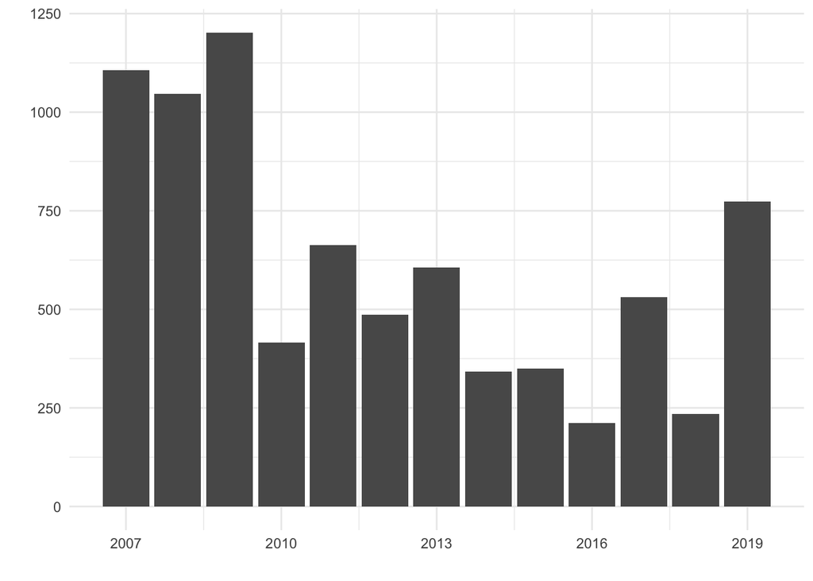

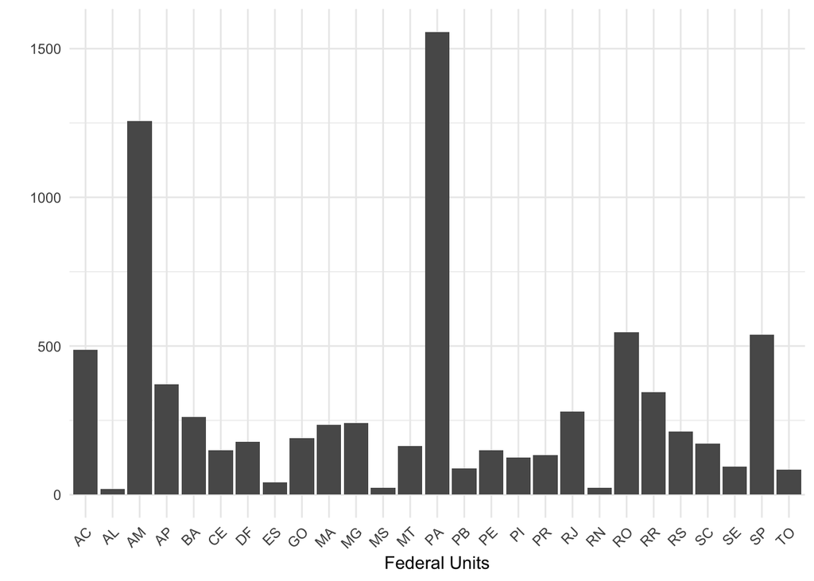

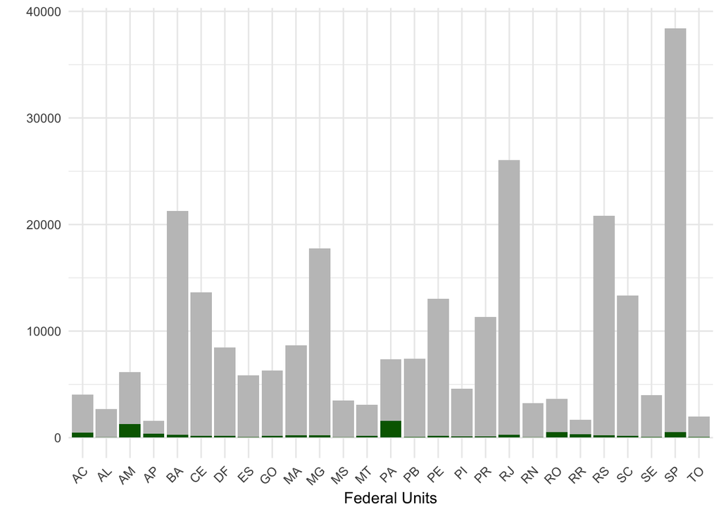

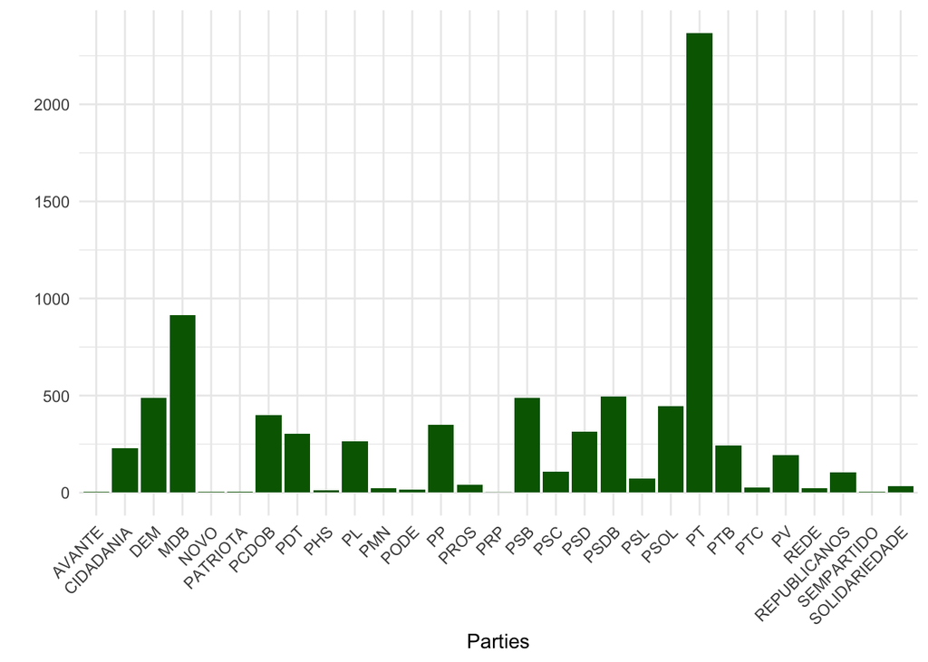

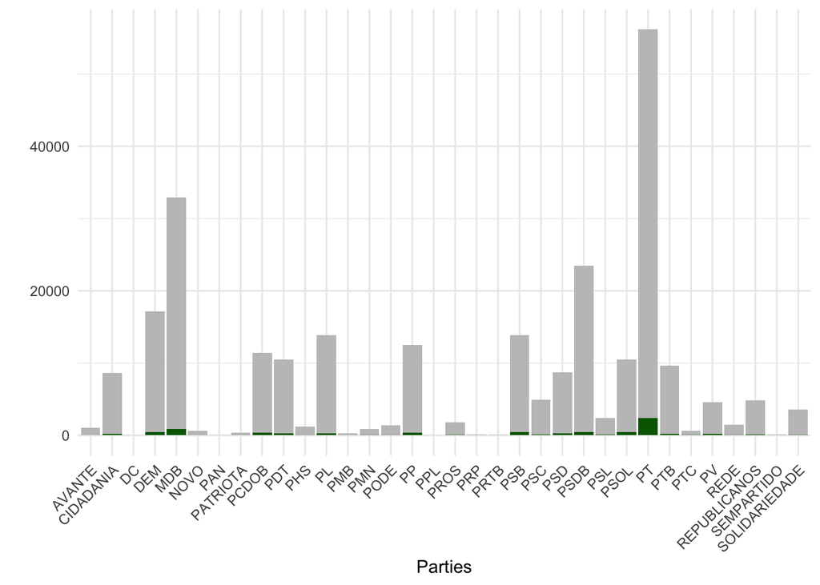

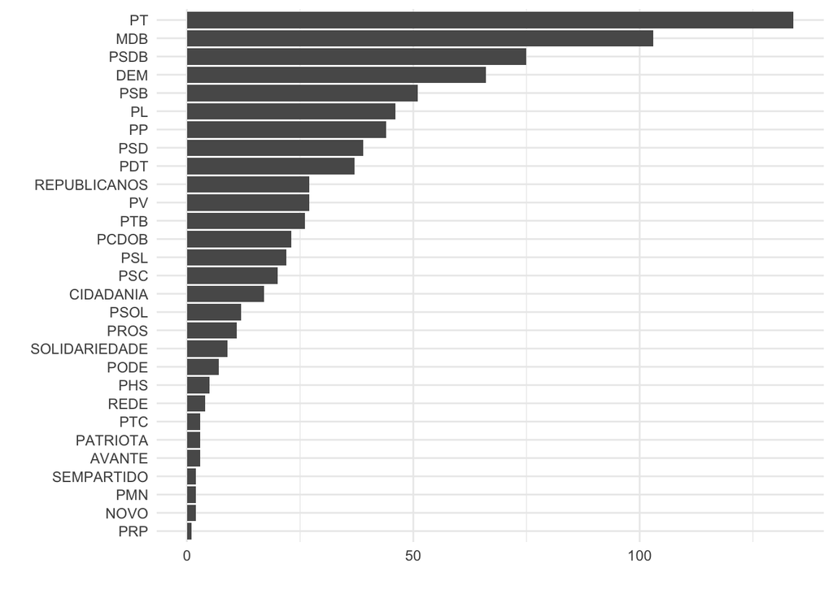

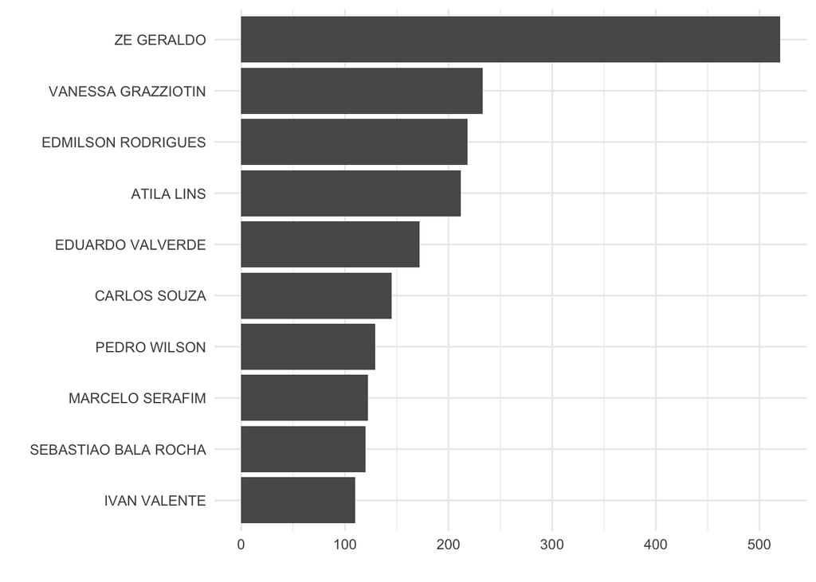

[figure not shown]

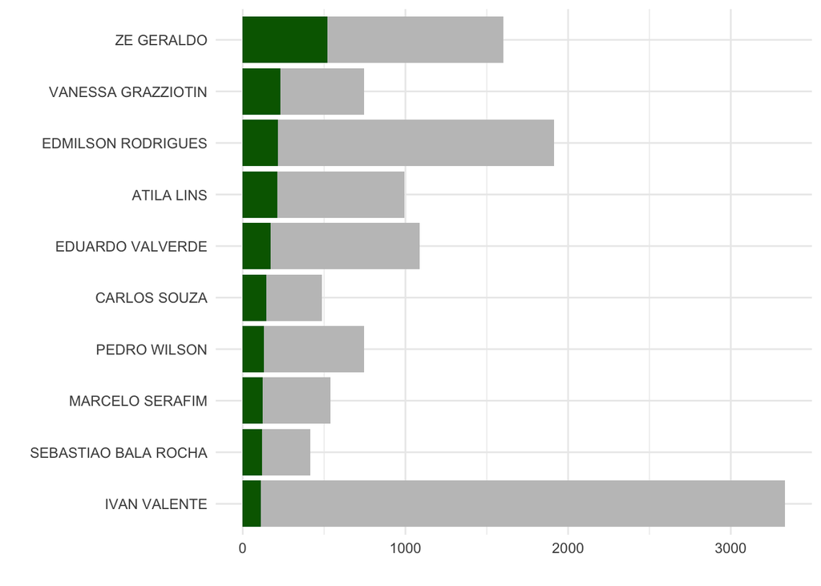